# Homework 10

Alex Steiner

2024-04-03

For loops and randomization tests

1. Using a for loop, write a function to calculate the number of zeroes in a numeric vector. Before entering the loop, set up a counter variable counter <- 0. Inside the loop, add 1 to counter each time you have a zero in the vector. Finally, use return(counter) for the output.

```r
vector <- c(1,0,2,3,4,5,0,50,4)
zerocounter <- 0

for(i in seq_along(vector)){
  if(vector[i] == 0){
    zerocounter <- zerocounter + 1
  }
  }
print(zerocounter)
```

```
## [1] 2
```

```r
##another way by Nic
#for(i in seq_along(vector)){
#  zerocounter <- zerocounter + as.numeric(vector[i] == 0)
#}



## how we would actually want to do this
sum(vector == 0)
```

```
## [1] 2
```

2. Use subsetting instead of a loop to rewrite the function as a single line of code.

```r
length(vector[vector == 0])
```

```
## [1] 2
```

3. Write a function that takes as input two integers representing the number of rows and columns in a matrix. The output is a matrix of these dimensions in which each element is the product of the row number x the column number.

```r
##probably not the best way to do this, but
matrixfuncout <- function(row = 4, column = 3){
  data = expand.grid(m = 1:row, n = 1:column)
  matmult <- data$m * data$n
  mat <- matrix(data = matmult, nrow = row, ncol = column)
print(mat)
  }

matrixfuncout()
```

```
##      [,1] [,2] [,3]
## [1,]    1    2    3
## [2,]    2    4    6
## [3,]    3    6    9
## [4,]    4    8   12
```

4.Now let’s practice calling custom functions within a for loop. Use the code from previous lectures on loops and functions to complete the following steps:

1. Simulate a dataset with 3 groups of data, each group drawn from a distribution with a different mean. The final data frame should have 1 column for group and 1 column for the response variable.

```r
groups <- c("groupa", "groupb", "groupc")
n <- 50
df <- data.frame(matrix(ncol = 2, nrow = n)) #temp df for the loop
df_total <- NULL  #resulting df

for(i in 1:length(groups)){
  df[1] <- rep(groups[i], each = n)    #puts one grouping var in df
  df[2] <- rnorm(n = n, mean = runif(1)) #generates n random numbers with random mean into df
      df_total <- rbind(df_total,df) #appends all dfs in loop
}

print(df_total)
```

```
##         X1           X2
## 1   groupa  2.190407209
## 2   groupa  1.051107519
## 3   groupa  0.742141672
## 4   groupa  0.305911644
## 5   groupa -0.589144900
## 6   groupa  1.070251513
## 7   groupa  1.767394849
## 8   groupa  2.469710875
## 9   groupa -0.064071404
## 10  groupa  1.578728131
## 11  groupa -0.301164672
## 12  groupa  1.802507891
## 13  groupa  0.804037383
## 14  groupa -0.464118684
```

[output cut: 136 more lines]

```r
#how I would actually do this with a for loop
df <- 1:50
df <- as.data.frame(df) #populate a dataframe
df
```

```
##    df
## 1   1
## 2   2
## 3   3
## 4   4
## 5   5
## 6   6
## 7   7
## 8   8
## 9   9
## 10 10
## 11 11
## 12 12
## 13 13
## 14 14
```

[output cut: 36 more lines]

```r
cols <- 3 #number of columns

for(i in 1:cols){
  col <- rnorm(n = 50, mean = runif(1))
  df[ , paste0("col", i)] <- col
}
print(df)
```

```
##    df        col1        col2         col3
## 1   1  0.86734702 -0.45810297  1.327368715
## 2   2  0.63543870  0.53628929  0.270053796
## 3   3  1.34984183 -1.37871487  1.140833546
## 4   4  0.69925139 -0.75154554  0.891952314
## 5   5  0.84527546  0.98041419  1.518976618
## 6   6  1.30800211  1.03190543  2.345208576
## 7   7 -0.44612084  1.08735606 -0.043895785
## 8   8  2.20701113  0.72138848 -0.729687300
## 9   9  1.14355826  1.84714688  1.418835679
## 10 10  0.39498192 -0.08111977  1.690408303
## 11 11  0.46391490  1.37428059 -0.977423356
## 12 12  0.49169668  0.61015421  0.449305192
## 13 13  3.81094315  1.32388164  0.101282438
## 14 14  0.17950323  0.61716052  1.477087029
```

[output cut: 36 more lines]

```r
library(tidyverse)
dfLong <- df %>% pivot_longer(cols = c("col1", "col2", "col3"), names_to = "Group", values_to = "Response" )
print(dfLong)
```

```
## # A tibble: 150 × 3
##       df Group Response
##    <int> <chr>    <dbl>
##  1     1 col1     0.867
##  2     1 col2    -0.458
##  3     1 col3     1.33
##  4     2 col1     0.635
##  5     2 col2     0.536
##  6     2 col3     0.270
##  7     3 col1     1.35
##  8     3 col2    -1.38
##  9     3 col3     1.14
## 10     4 col1     0.699
## # ℹ 140 more rows
```

2. Write a custom function that 1) reshuffles the response variable, and 2) calculates the mean of each group in the reshuffled data. Store the means in a vector of length 3.

```r
mean <- NULL
means <-NULL
groups <- c("groupa", "groupb", "groupc")

shufflefunc <- function(df = df_total, group = groups){
    df$X2 <- sample(df$X2, replace = FALSE) #reshuffle
    for(j in 1:length(group)){ #for loop to calc mean of each group
             tempgroup <- subset(df, (df$X1 == group[j])) #subsets the df to the group it is working on (a b or c)
             mean <- mean(tempgroup$X2) #takes mean of subset
             means <- append(means, mean) #pastes mean to the end of the means list
    }
return(means)
}

df_total
```

```
##         X1           X2
## 1   groupa  2.190407209
## 2   groupa  1.051107519
## 3   groupa  0.742141672
## 4   groupa  0.305911644
## 5   groupa -0.589144900
## 6   groupa  1.070251513
## 7   groupa  1.767394849
## 8   groupa  2.469710875
## 9   groupa -0.064071404
## 10  groupa  1.578728131
## 11  groupa -0.301164672
## 12  groupa  1.802507891
## 13  groupa  0.804037383
## 14  groupa -0.464118684
```

[output cut: 136 more lines]

```r
shuffmeans <- shufflefunc()
print(shuffmeans)  ##why are they all really close?
```

```
## [1] 0.8739195 0.6900864 0.5908232
```

3. Use a for loop to repeat the function in b 100 times. Store the results in a data frame that has 1 column indicating the replicate number and 1 column for each new group mean, for a total of 4 columns.

```r
repete <- 1:100  #if Pete and Repeat were in a boat and Pete fell out, who was left? :||
df_rep <- data.frame(NULL)
df_final <- NULL
groups <- c("groupa", "groupb", "groupc")


for(i in 1:length(repete)){
  repz <- rep(i, 3)
  meanshuff <- shufflefunc()
  emptycolumn <- NA #not sure what this column should be?
  df_rep <- data.frame(groups, meanshuff, emptycolumn, repz)
  df_final <- rbind(df_final,df_rep)
  }
print(df_final)
```

```
##     groups meanshuff emptycolumn repz
## 1   groupa 0.6784993          NA    1
## 2   groupb 0.6988133          NA    1
## 3   groupc 0.7775164          NA    1
## 4   groupa 0.8121456          NA    2
## 5   groupb 0.7881860          NA    2
## 6   groupc 0.5544975          NA    2
## 7   groupa 0.7071507          NA    3
## 8   groupb 0.7731906          NA    3
## 9   groupc 0.6744878          NA    3
## 10  groupa 0.7226121          NA    4
## 11  groupb 0.7477036          NA    4
## 12  groupc 0.6845135          NA    4
## 13  groupa 0.6906791          NA    5
## 14  groupb 0.8315147          NA    5
```

[output cut: 286 more lines]

4. Use qplot() to create a histogram of the means for each reshuffled group. Or, if you want a challenge, use ggplot() to overlay all 3 histograms in the same figure. How do the distributions of reshuffled means compare to the original means?

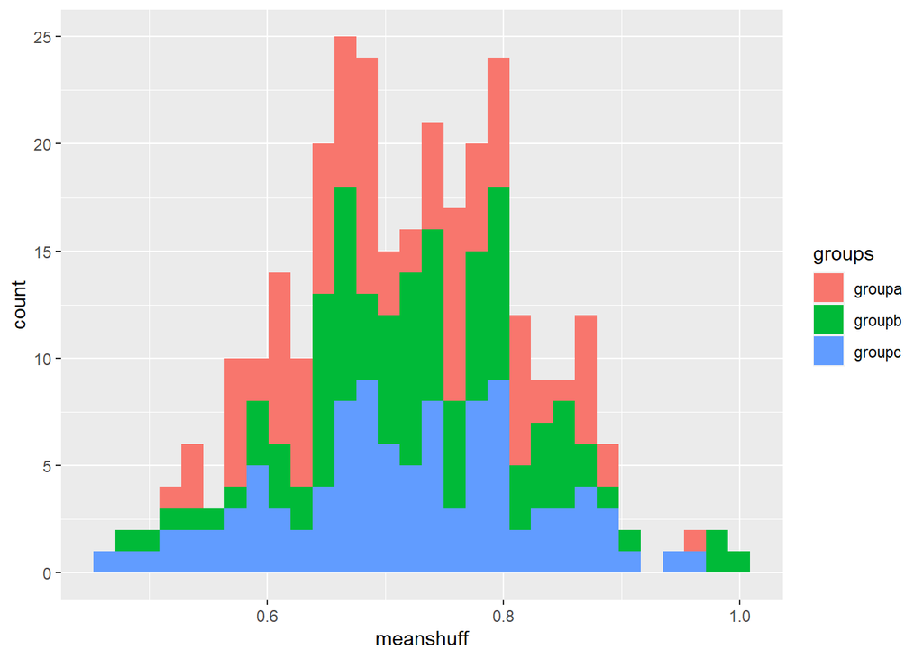

```r
library(ggplot2)


ggplot(data = df_final) +
  aes(x = meanshuff, fill = groups) +
  geom_histogram()
```

```r
aggregate(x= df_final$meanshuff,
                      # Specify group indicator
                      by = list(df_final$groups),
                      # Specify function (i.e. mean)
                      FUN = mean)
```

```
##   Group.1         x
## 1  groupa 0.7108644
## 2  groupb 0.7290201
## 3  groupc 0.7149446
```